# Exploratory data analysis and summarization of white wine data

Shreyas Raghavan

8 March 2018

## Exploratory Data Analysis of the White Wine dataset

The project is aimed at looking and finding deep insights of the white wine dataset. The report also aims in bringing us to a conclusion so as to what are the factors that affect the quality of wine.

### Data and Types

The data is in csv format.In computing, a comma-separated values (CSV) file stores tabular data (numbers and text) in plain text. Each line of the file is a data record. Each record consists of one or more fields, separated by commas.

All wines are produced in a particular area of Portugal. Data are collected on 12 different properties of the wines one of which is Quality, based on sensory data, and the rest are on chemical properties of the wines including density, acidity, alcohol content etc. All chemical properties of wines are continuous variables. Quality is an ordinal variable with possible ranking from 1 (worst) to 10 (best). Each variety of wine is tasted by three independent tasters and the final rank assigned is the median rank given by the tasters.

**Attribute Information:**

For more information, read [Cortez et al., 2009]. Input variables (based on physicochemical tests): 1 - fixed acidity 2 - volatile acidity 3 - citric acid 4 - residual sugar 5 - chlorides 6 - free sulfur dioxide 7 - total sulfur dioxide 8 - density 9 - pH 10 - sulphates 11 - alcohol Output variable (based on sensory data): 12 - quality (score between 0 and 10)

### Importing the dataset

We import the dataset by using the read_csv function of R. We then , save it in dataframe format. In our case we have assigned variable name df.

```r
df = read.csv("wineQualityWhites.csv")
```

```
##   X fixed.acidity volatile.acidity citric.acid residual.sugar chlorides
## 1 1           7.0             0.27        0.36           20.7     0.045
## 2 2           6.3             0.30        0.34            1.6     0.049
## 3 3           8.1             0.28        0.40            6.9     0.050
## 4 4           7.2             0.23        0.32            8.5     0.058
## 5 5           7.2             0.23        0.32            8.5     0.058
## 6 6           8.1             0.28        0.40            6.9     0.050
##   free.sulfur.dioxide total.sulfur.dioxide density   pH sulphates alcohol
## 1                  45                  170  1.0010 3.00      0.45     8.8
## 2                  14                  132  0.9940 3.30      0.49     9.5
## 3                  30                   97  0.9951 3.26      0.44    10.1
## 4                  47                  186  0.9956 3.19      0.40     9.9
## 5                  47                  186  0.9956 3.19      0.40     9.9
## 6                  30                   97  0.9951 3.26      0.44    10.1
##   quality
## 1       6
## 2       6
## 3       6
## 4       6
## 5       6
## 6       6
```

As we could see that we’ve a column named ‘X’ which basically is the index. We won’t be using that column for any of our computation since we won’t actually gain any insights about the problem statement.

Dataframe after removing the columns ‘X’

```r
head(df)
```

```
##   fixed.acidity volatile.acidity citric.acid residual.sugar chlorides
## 1           7.0             0.27        0.36           20.7     0.045
## 2           6.3             0.30        0.34            1.6     0.049
## 3           8.1             0.28        0.40            6.9     0.050
## 4           7.2             0.23        0.32            8.5     0.058
## 5           7.2             0.23        0.32            8.5     0.058
## 6           8.1             0.28        0.40            6.9     0.050
##   free.sulfur.dioxide total.sulfur.dioxide density   pH sulphates alcohol
## 1                  45                  170  1.0010 3.00      0.45     8.8
## 2                  14                  132  0.9940 3.30      0.49     9.5
## 3                  30                   97  0.9951 3.26      0.44    10.1
## 4                  47                  186  0.9956 3.19      0.40     9.9
## 5                  47                  186  0.9956 3.19      0.40     9.9
## 6                  30                   97  0.9951 3.26      0.44    10.1
##   quality
## 1       6
## 2       6
## 3       6
## 4       6
## 5       6
## 6       6
```

### Statistical summary of the data

```
##  fixed.acidity    volatile.acidity  citric.acid     residual.sugar
##  Min.   : 3.800   Min.   :0.0800   Min.   :0.0000   Min.   : 0.600
##  1st Qu.: 6.300   1st Qu.:0.2100   1st Qu.:0.2700   1st Qu.: 1.700
##  Median : 6.800   Median :0.2600   Median :0.3200   Median : 5.200
##  Mean   : 6.855   Mean   :0.2782   Mean   :0.3342   Mean   : 6.391
##  3rd Qu.: 7.300   3rd Qu.:0.3200   3rd Qu.:0.3900   3rd Qu.: 9.900
##  Max.   :14.200   Max.   :1.1000   Max.   :1.6600   Max.   :65.800
##    chlorides       free.sulfur.dioxide total.sulfur.dioxide
##  Min.   :0.00900   Min.   :  2.00      Min.   :  9.0
##  1st Qu.:0.03600   1st Qu.: 23.00      1st Qu.:108.0
##  Median :0.04300   Median : 34.00      Median :134.0
##  Mean   :0.04577   Mean   : 35.31      Mean   :138.4
##  3rd Qu.:0.05000   3rd Qu.: 46.00      3rd Qu.:167.0
##  Max.   :0.34600   Max.   :289.00      Max.   :440.0
##     density             pH          sulphates         alcohol
##  Min.   :0.9871   Min.   :2.720   Min.   :0.2200   Min.   : 8.00
##  1st Qu.:0.9917   1st Qu.:3.090   1st Qu.:0.4100   1st Qu.: 9.50
##  Median :0.9937   Median :3.180   Median :0.4700   Median :10.40
##  Mean   :0.9940   Mean   :3.188   Mean   :0.4898   Mean   :10.51
##  3rd Qu.:0.9961   3rd Qu.:3.280   3rd Qu.:0.5500   3rd Qu.:11.40
##  Max.   :1.0390   Max.   :3.820   Max.   :1.0800   Max.   :14.20
##     quality
##  Min.   :3.000
##  1st Qu.:5.000
##  Median :6.000
##  Mean   :5.878
##  3rd Qu.:6.000
##  Max.   :9.000
```

The statistics about the data tells us that it has been recorded in one of the wine sample that total sulpher dioxide is 440.0 it is also worth noting that the free sulpher dioxide in one of the sample is 289.0 as maximum and minimum value recorded for the very same is 2.0

The mean noted for the quality of wine is 5.878. We would now dive deep into seeing what factors affect the quality of wine.

### Univariate plots

The count of each individual value of quality of wine is plotted below.

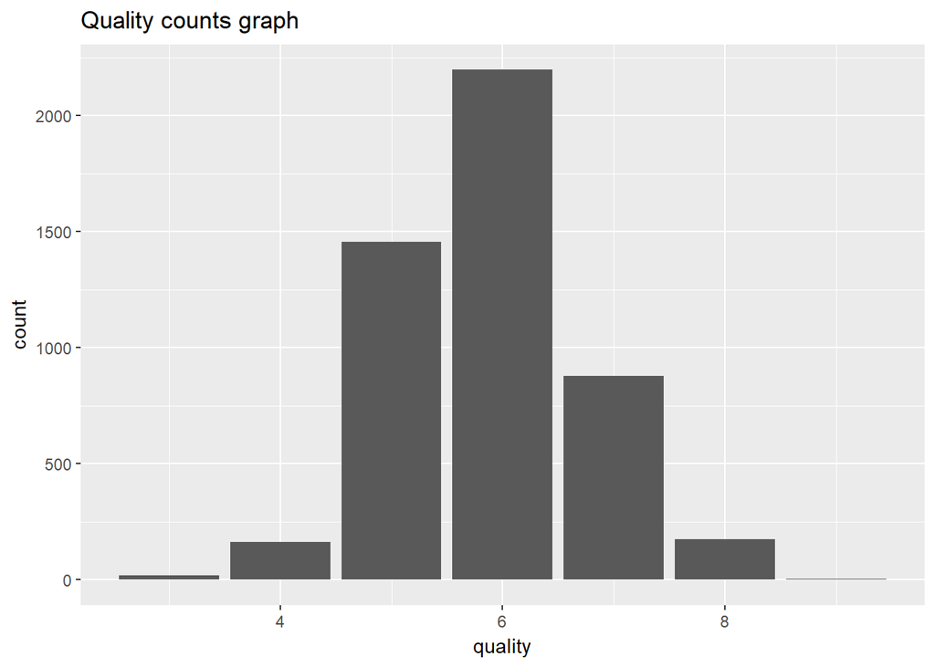

```
##    Min. 1st Qu.  Median    Mean 3rd Qu.    Max.
##   3.000   5.000   6.000   5.878   6.000   9.000
```

The **fixed acidity** graph is plotted below. This graph represents the occurance of the values.

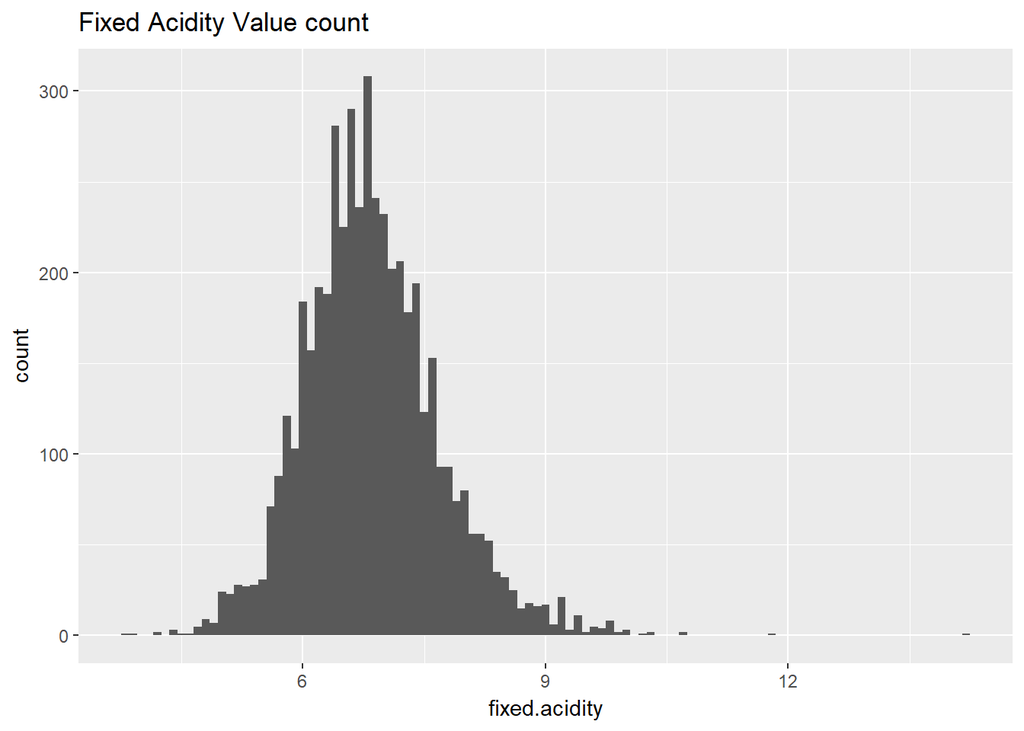

The **volatile acidity** graph is plotted below.

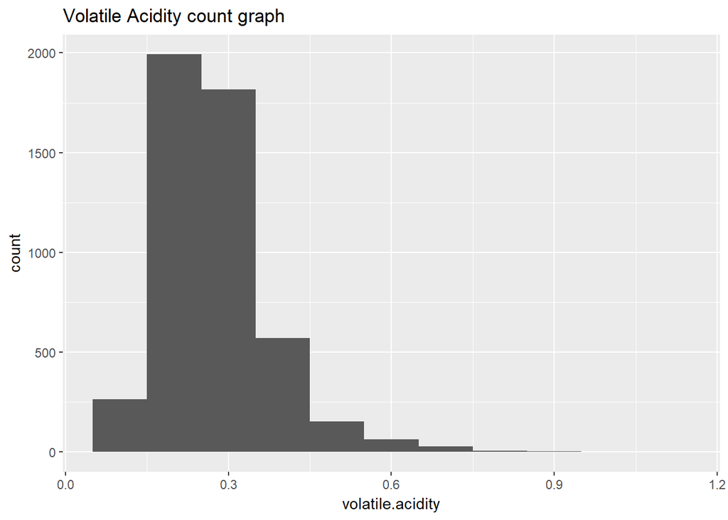

The values are continuous in case of volatile acidity. Although there are outliers, there isn’t any disctinct outlier which we should worry about at the moment.

The next graph would be the **citrus acid** count graph.

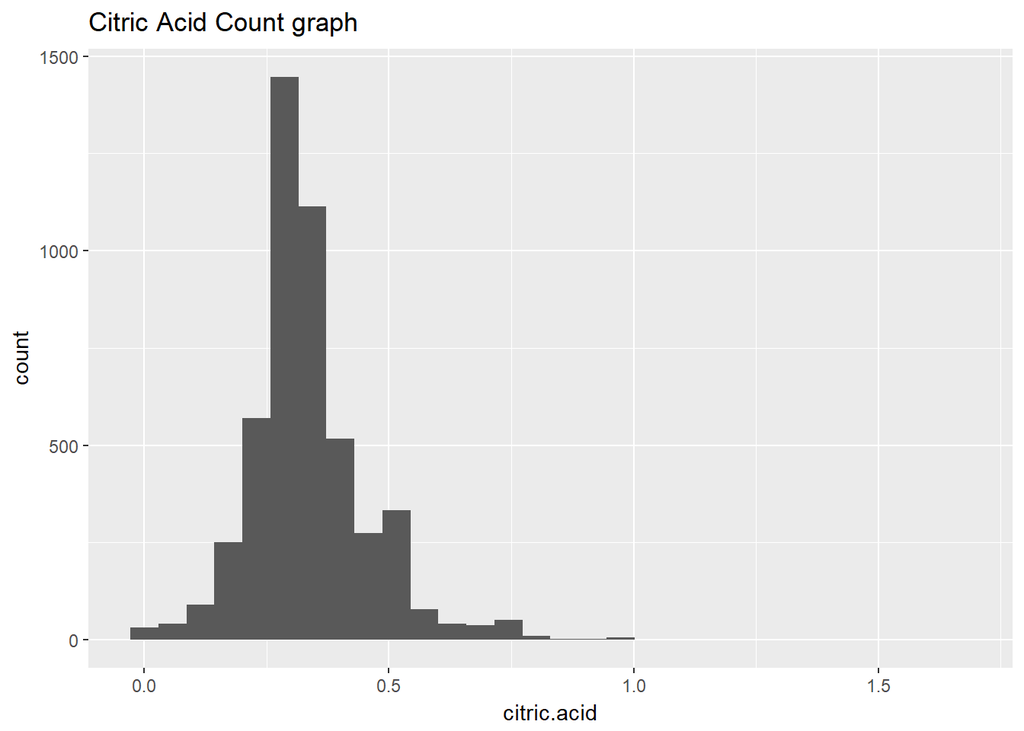

The values are continuous and we do not have any distinct outlier. But as we can see from the graph, we have more amount of occurance of citrus acid having values somewhere around 0.25.

The next graph would be for **residual sugar**

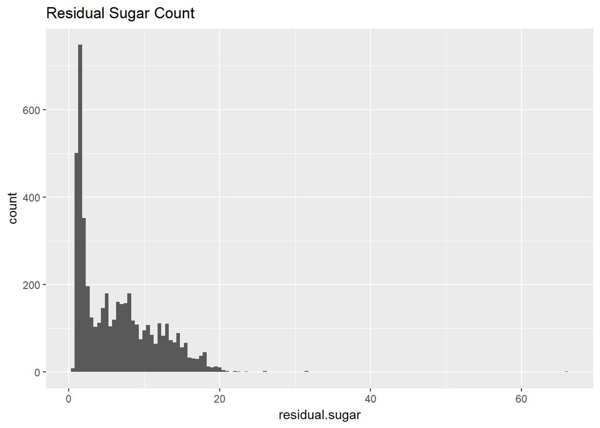

As the value for residual sugar increases, the count reduces. There are some outliers present around points 30 and 65.

The graph for **Cloride count** is plotted below.

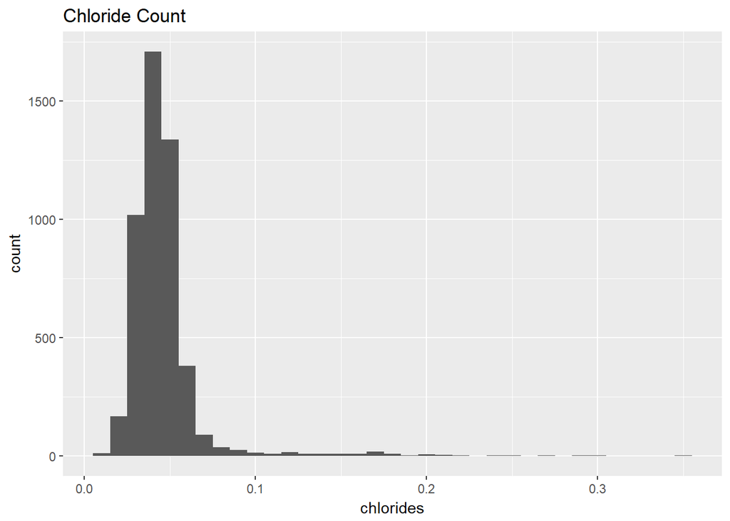

```
##    Min. 1st Qu.  Median    Mean 3rd Qu.    Max.
## 0.00900 0.03600 0.04300 0.04577 0.05000 0.34600
```

We could see that the mean of chlorides is 0.04577.

The graph for **Alcohol count** is plotted below.

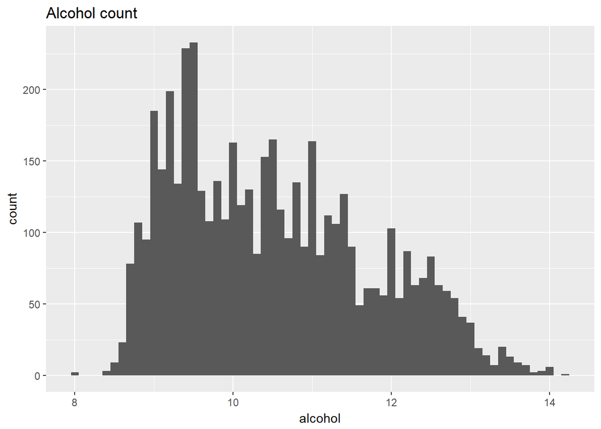

The mean of alcohol count is 10.51 while the maximum value is 14.20.

The graph for **Free Sulphur Dioxide Count** is plotted below.

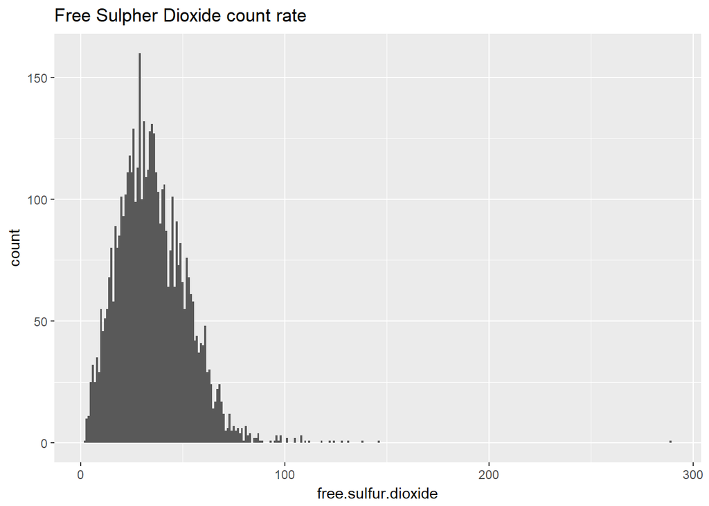

We can see from the graph that average value for free sulphur dioxide is around 35. There are some outliers present, after 80.

Plotted below is the graph for **Total Sulphur Dioxide count**

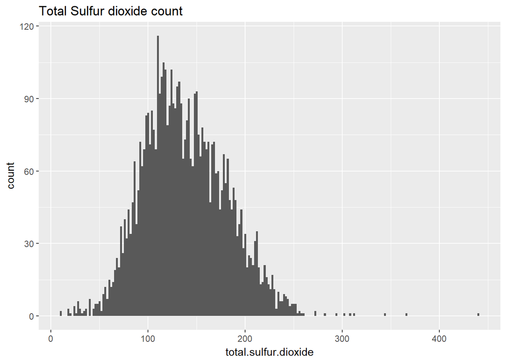

Plotted below is the garph for **pH count**

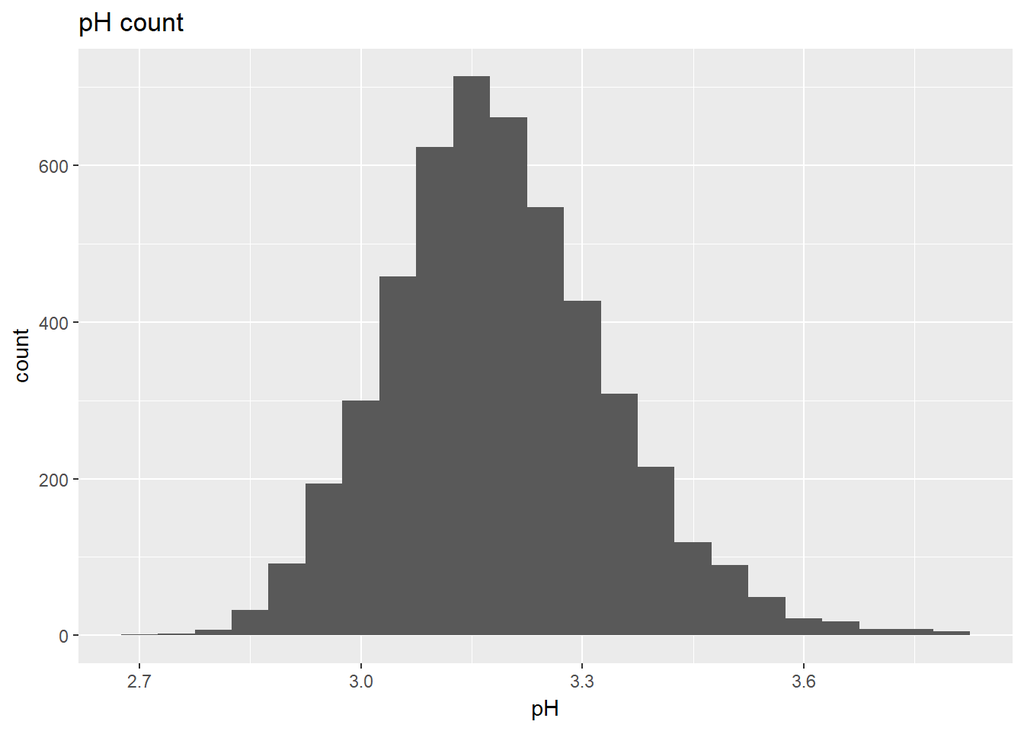

The graph is continuous, where the value of pH with maximum counts is 3.18.

The graph plotted below is for **Density count**

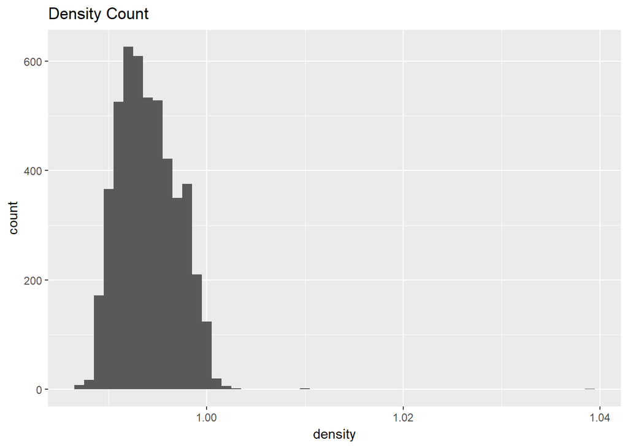

The graph for **Sulphates count** is plotted below.

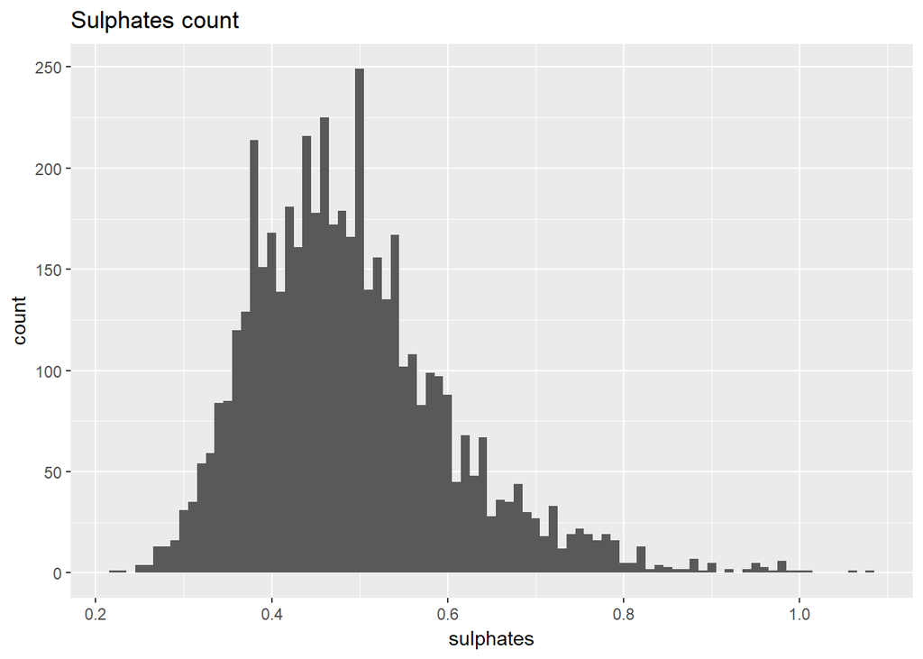

### Inference from Univariate Analysis

```r
df_rmout = subset(df,residual.sugar < 25)
df_rmout = subset(df,total.sulfur.dioxide < 300)
df_rmout = subset(df,density < 1.005)
df_rmout = subset(df,free.sulfur.dioxide < 150)
```

```
##  fixed.acidity    volatile.acidity  citric.acid     residual.sugar
##  Min.   : 3.800   Min.   :0.0800   Min.   :0.0000   Min.   : 0.600
##  1st Qu.: 6.300   1st Qu.:0.2100   1st Qu.:0.2700   1st Qu.: 1.700
##  Median : 6.800   Median :0.2600   Median :0.3200   Median : 5.200
##  Mean   : 6.855   Mean   :0.2782   Mean   :0.3342   Mean   : 6.392
##  3rd Qu.: 7.300   3rd Qu.:0.3200   3rd Qu.:0.3900   3rd Qu.: 9.900
##  Max.   :14.200   Max.   :1.1000   Max.   :1.6600   Max.   :65.800
##    chlorides       free.sulfur.dioxide total.sulfur.dioxide
##  Min.   :0.00900   Min.   :  2.00      Min.   :  9.0
##  1st Qu.:0.03600   1st Qu.: 23.00      1st Qu.:108.0
##  Median :0.04300   Median : 34.00      Median :134.0
##  Mean   :0.04577   Mean   : 35.26      Mean   :138.3
##  3rd Qu.:0.05000   3rd Qu.: 46.00      3rd Qu.:167.0
##  Max.   :0.34600   Max.   :146.50      Max.   :366.5
##     density             pH          sulphates         alcohol
##  Min.   :0.9871   Min.   :2.720   Min.   :0.2200   Min.   : 8.00
##  1st Qu.:0.9917   1st Qu.:3.090   1st Qu.:0.4100   1st Qu.: 9.50
##  Median :0.9937   Median :3.180   Median :0.4700   Median :10.40
##  Mean   :0.9940   Mean   :3.188   Mean   :0.4898   Mean   :10.51
##  3rd Qu.:0.9961   3rd Qu.:3.280   3rd Qu.:0.5500   3rd Qu.:11.40
##  Max.   :1.0390   Max.   :3.820   Max.   :1.0800   Max.   :14.20
##     quality
##  Min.   :3.000
##  1st Qu.:5.000
##  Median :6.000
##  Mean   :5.878
##  3rd Qu.:6.000
##  Max.   :9.000
```

### The new univariate plots.

*** Quality ***

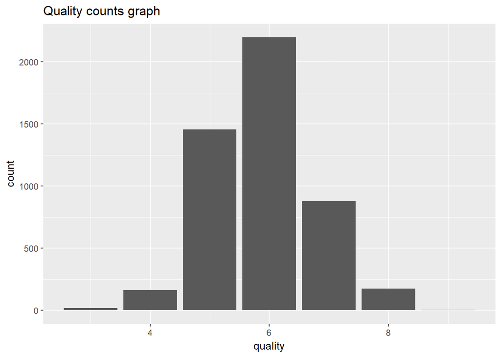

```
##    Min. 1st Qu.  Median    Mean 3rd Qu.    Max.
##   3.000   5.000   6.000   5.878   6.000   9.000
```

** Fixed Acidity **

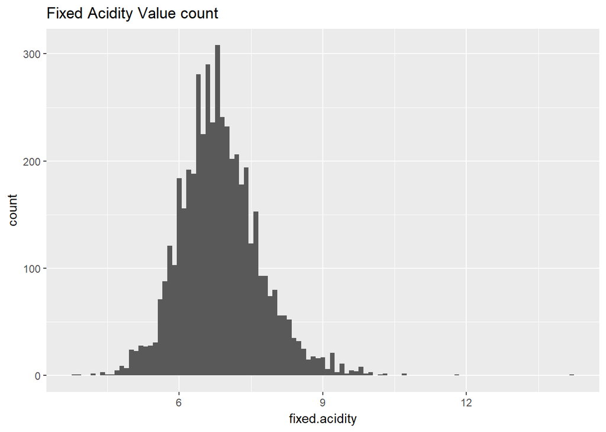

** Volatile Acidity **

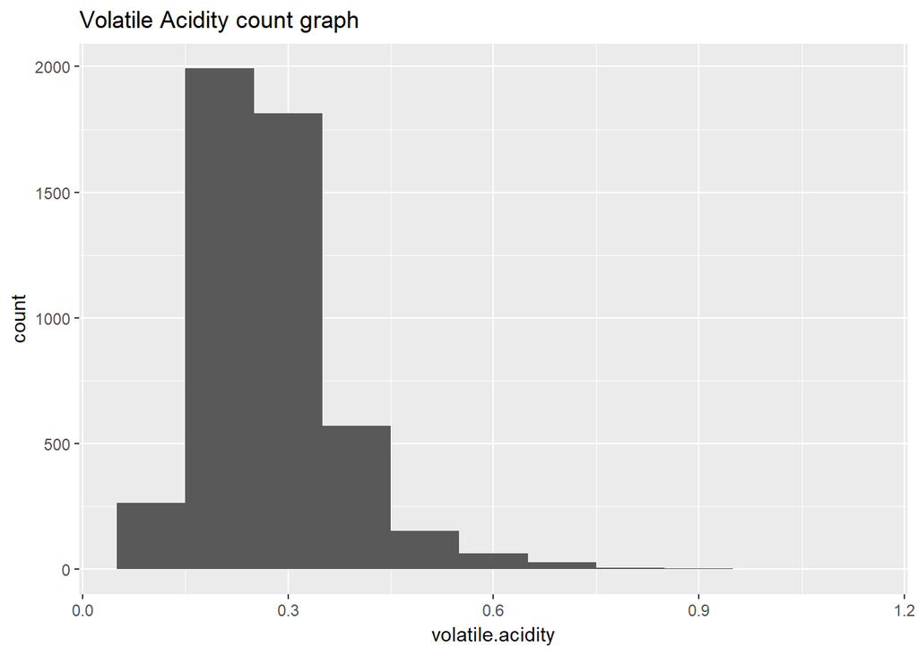

** Citric Acid **

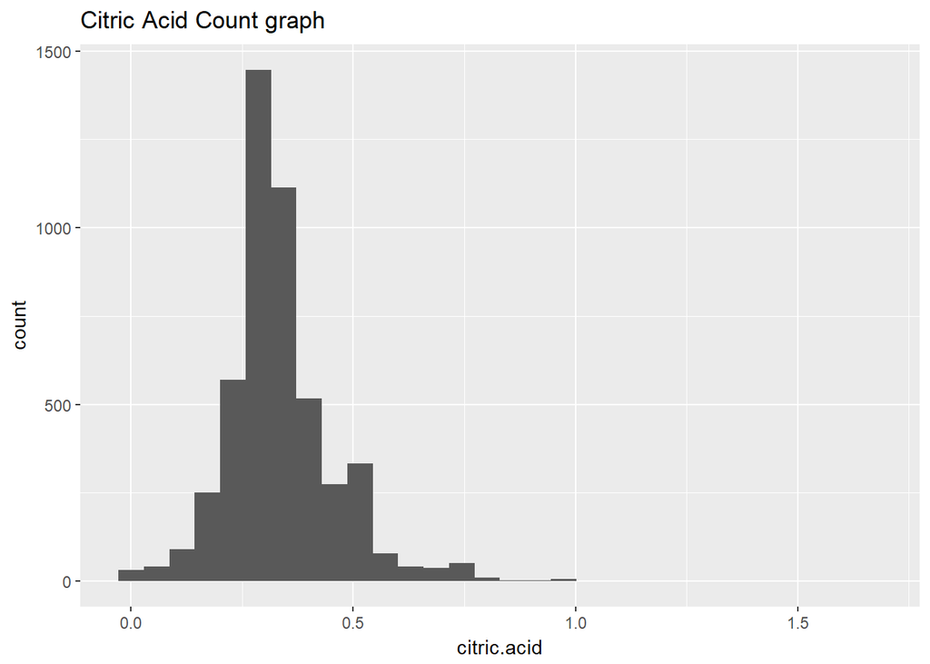

**residual sugar**

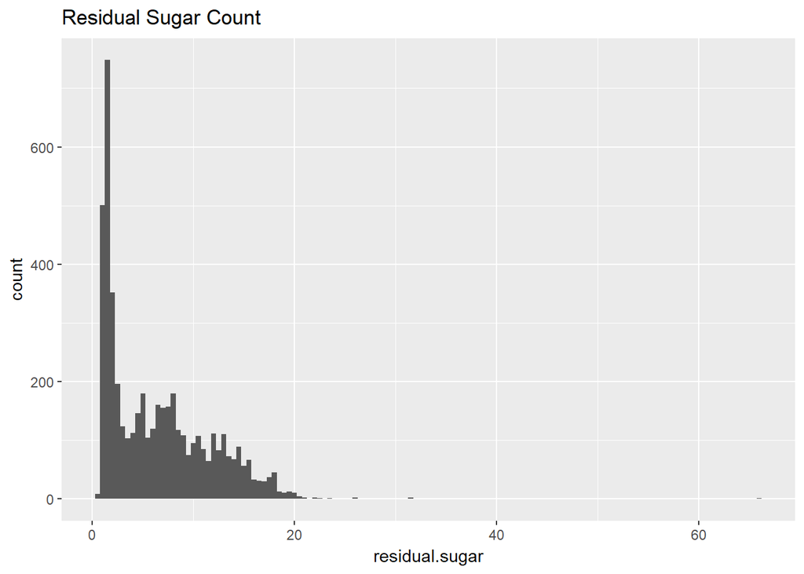

**Alcohol count**

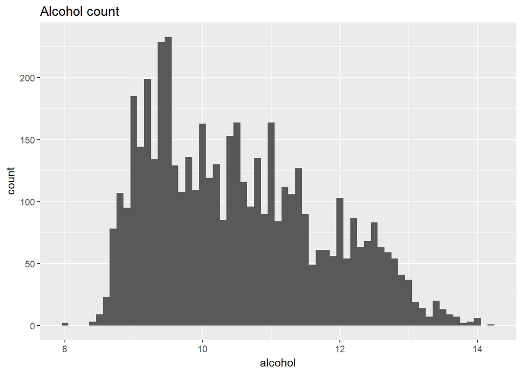

**Free Sulphur Dioxide Count**

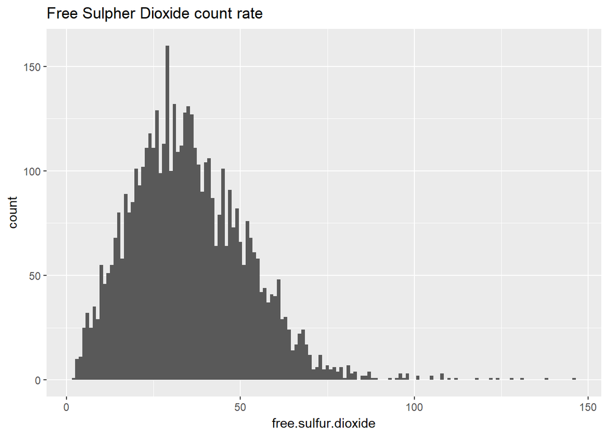

**Density count**

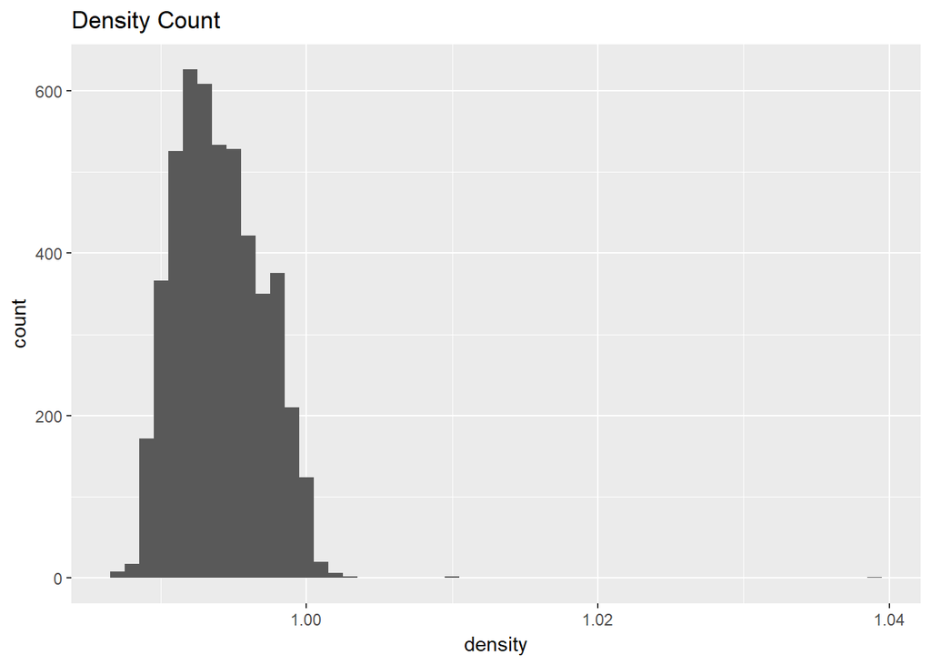

**Sulphates count**

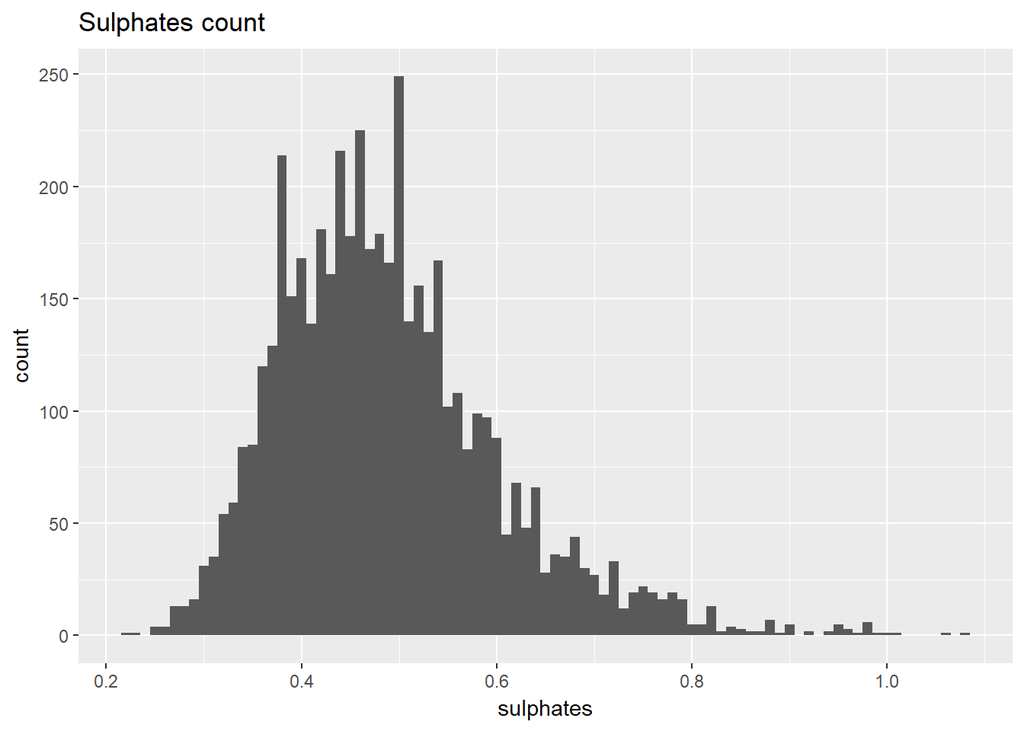

**Total Sulphur Dioxide count**

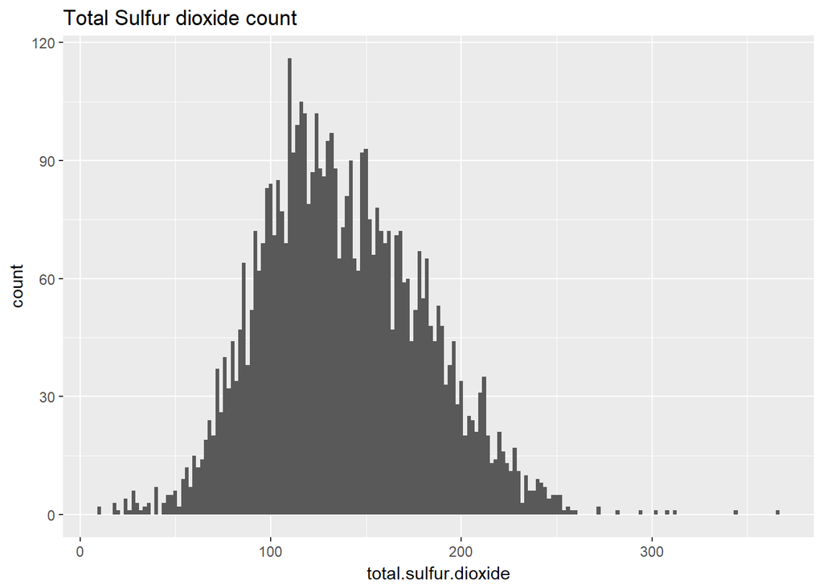

**pH count**

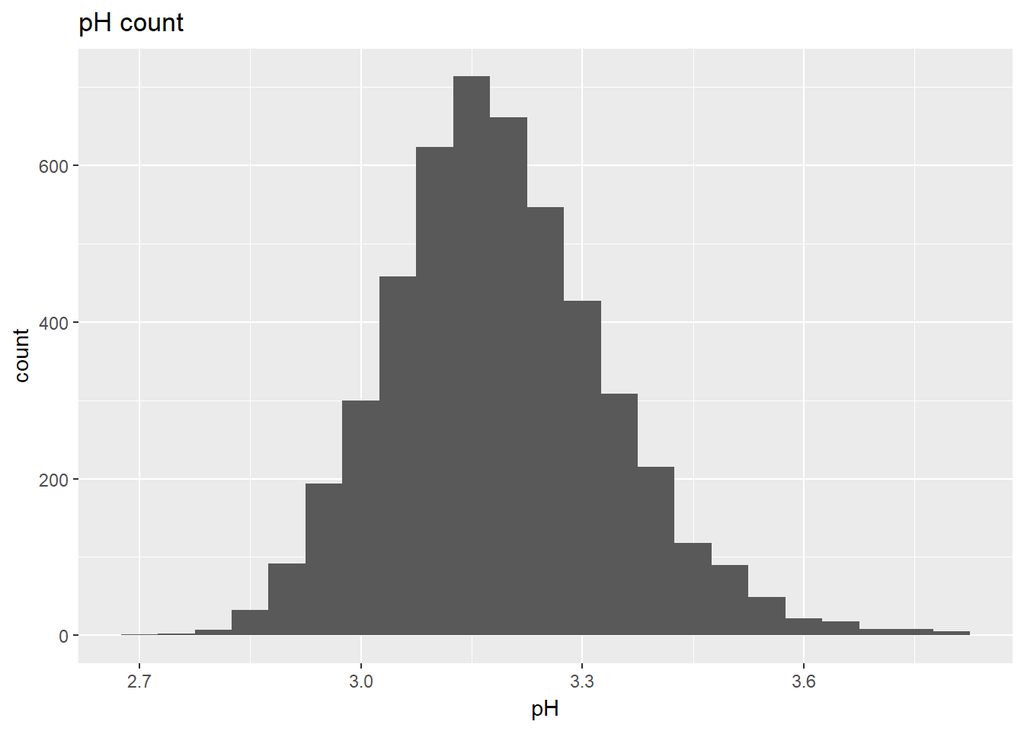

## Further inference

We have also used segments to classify the wine quality , These segmentation is done to three ( average , good , great ). Also created a column called ratio which specify the ratio of SO2 in the wine.

The ratio calculations are free sulpher dioxide / total sulpher dioxide.

```r
df_rmout$class = cut(df_rmout$quality,breaks=c(0,4,6,9),labels=c("average","good","great"))
df_rmout$ratio = (df_rmout$free.sulfur.dioxide/df_rmout$total.sulfur.dioxide)
```

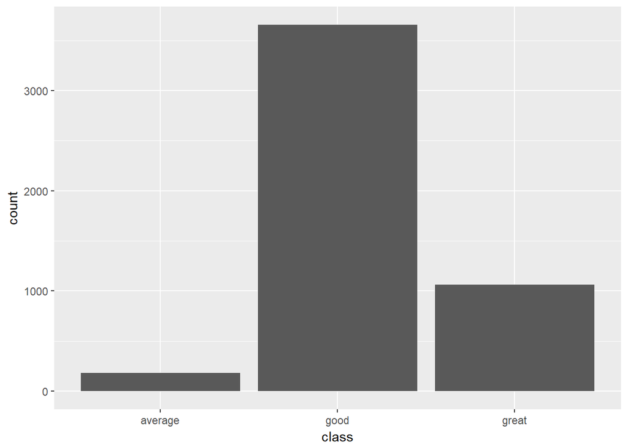

Our final table before bivariate analysis looks like as follows ,

```
##   fixed.acidity volatile.acidity citric.acid residual.sugar chlorides
## 1           7.0             0.27        0.36           20.7     0.045
## 2           6.3             0.30        0.34            1.6     0.049
## 3           8.1             0.28        0.40            6.9     0.050
## 4           7.2             0.23        0.32            8.5     0.058
## 5           7.2             0.23        0.32            8.5     0.058
## 6           8.1             0.28        0.40            6.9     0.050
##   free.sulfur.dioxide total.sulfur.dioxide density   pH sulphates alcohol
## 1                  45                  170  1.0010 3.00      0.45     8.8
## 2                  14                  132  0.9940 3.30      0.49     9.5
## 3                  30                   97  0.9951 3.26      0.44    10.1
## 4                  47                  186  0.9956 3.19      0.40     9.9
## 5                  47                  186  0.9956 3.19      0.40     9.9
## 6                  30                   97  0.9951 3.26      0.44    10.1
##   quality class     ratio
## 1       6  good 0.2647059
## 2       6  good 0.1060606
## 3       6  good 0.3092784
## 4       6  good 0.2526882
## 5       6  good 0.2526882
## 6       6  good 0.3092784
```

and summary of the data would be

```
##  fixed.acidity    volatile.acidity  citric.acid     residual.sugar
##  Min.   : 3.800   Min.   :0.0800   Min.   :0.0000   Min.   : 0.600
##  1st Qu.: 6.300   1st Qu.:0.2100   1st Qu.:0.2700   1st Qu.: 1.700
##  Median : 6.800   Median :0.2600   Median :0.3200   Median : 5.200
##  Mean   : 6.855   Mean   :0.2782   Mean   :0.3342   Mean   : 6.392
##  3rd Qu.: 7.300   3rd Qu.:0.3200   3rd Qu.:0.3900   3rd Qu.: 9.900
##  Max.   :14.200   Max.   :1.1000   Max.   :1.6600   Max.   :65.800
##    chlorides       free.sulfur.dioxide total.sulfur.dioxide
##  Min.   :0.00900   Min.   :  2.00      Min.   :  9.0
##  1st Qu.:0.03600   1st Qu.: 23.00      1st Qu.:108.0
##  Median :0.04300   Median : 34.00      Median :134.0
##  Mean   :0.04577   Mean   : 35.26      Mean   :138.3
##  3rd Qu.:0.05000   3rd Qu.: 46.00      3rd Qu.:167.0
##  Max.   :0.34600   Max.   :146.50      Max.   :366.5
##     density             pH          sulphates         alcohol
##  Min.   :0.9871   Min.   :2.720   Min.   :0.2200   Min.   : 8.00
##  1st Qu.:0.9917   1st Qu.:3.090   1st Qu.:0.4100   1st Qu.: 9.50
##  Median :0.9937   Median :3.180   Median :0.4700   Median :10.40
##  Mean   :0.9940   Mean   :3.188   Mean   :0.4898   Mean   :10.51
##  3rd Qu.:0.9961   3rd Qu.:3.280   3rd Qu.:0.5500   3rd Qu.:11.40
##  Max.   :1.0390   Max.   :3.820   Max.   :1.0800   Max.   :14.20
##     quality          class          ratio
##  Min.   :3.000   average: 182   Min.   :0.02362
##  1st Qu.:5.000   good   :3655   1st Qu.:0.19091
##  Median :6.000   great  :1060   Median :0.25362
##  Mean   :5.878                  Mean   :0.25550
##  3rd Qu.:6.000                  3rd Qu.:0.31579
##  Max.   :9.000                  Max.   :0.71053
```

As opposed to previous data which is ,

```
##  fixed.acidity    volatile.acidity  citric.acid     residual.sugar
##  Min.   : 3.800   Min.   :0.0800   Min.   :0.0000   Min.   : 0.600
##  1st Qu.: 6.300   1st Qu.:0.2100   1st Qu.:0.2700   1st Qu.: 1.700
##  Median : 6.800   Median :0.2600   Median :0.3200   Median : 5.200
##  Mean   : 6.855   Mean   :0.2782   Mean   :0.3342   Mean   : 6.391
##  3rd Qu.: 7.300   3rd Qu.:0.3200   3rd Qu.:0.3900   3rd Qu.: 9.900
##  Max.   :14.200   Max.   :1.1000   Max.   :1.6600   Max.   :65.800
##    chlorides       free.sulfur.dioxide total.sulfur.dioxide
##  Min.   :0.00900   Min.   :  2.00      Min.   :  9.0
##  1st Qu.:0.03600   1st Qu.: 23.00      1st Qu.:108.0
##  Median :0.04300   Median : 34.00      Median :134.0
##  Mean   :0.04577   Mean   : 35.31      Mean   :138.4
##  3rd Qu.:0.05000   3rd Qu.: 46.00      3rd Qu.:167.0
##  Max.   :0.34600   Max.   :289.00      Max.   :440.0
##     density             pH          sulphates         alcohol
##  Min.   :0.9871   Min.   :2.720   Min.   :0.2200   Min.   : 8.00
##  1st Qu.:0.9917   1st Qu.:3.090   1st Qu.:0.4100   1st Qu.: 9.50
##  Median :0.9937   Median :3.180   Median :0.4700   Median :10.40
##  Mean   :0.9940   Mean   :3.188   Mean   :0.4898   Mean   :10.51
##  3rd Qu.:0.9961   3rd Qu.:3.280   3rd Qu.:0.5500   3rd Qu.:11.40
##  Max.   :1.0390   Max.   :3.820   Max.   :1.0800   Max.   :14.20
##     quality
##  Min.   :3.000
##  1st Qu.:5.000
##  Median :6.000
##  Mean   :5.878
##  3rd Qu.:6.000
##  Max.   :9.000
```

## Bivariate analysis

The analysis takes comparsion between two variables and tries to establish/show relationship between them.

Let’s take a look at Correlation plot which was made using GGally library.

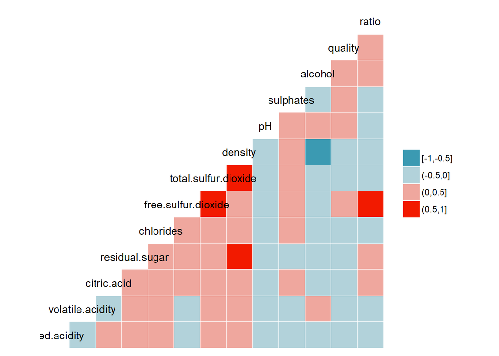

By the graph we could see strong relations between density and residual sugar , total sulpher and free sulpher as well as negative relation (but strong) between alcohol and density. It would be further interesting to see these effects on the total quality of the wine.

The most significant could be the relation between the wine quality ( the class column ) and alcohol, a relation could be established. We can take a look at it.

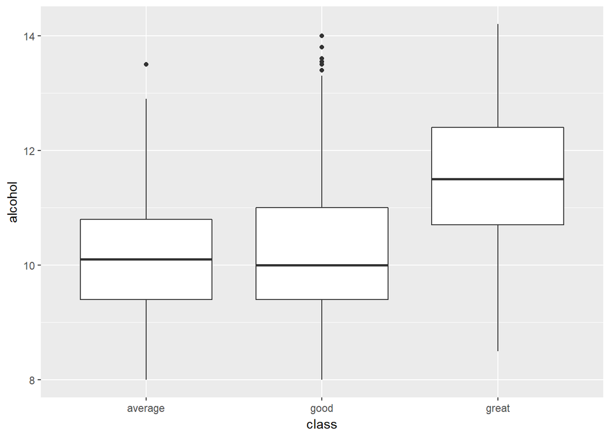

The relation between higher quality wine and alcohol seems to make more sense.

The density graph for the same can be seen.

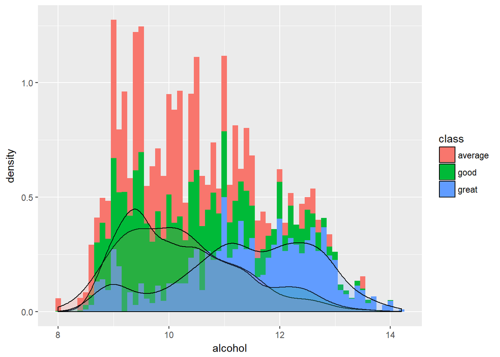

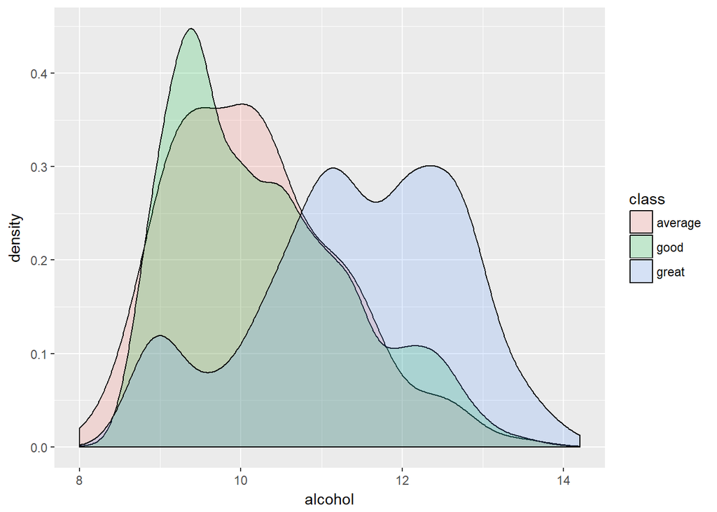

By the two graph above we can see that more alcohol means wine is great but , it’s not particularly enough to establish that relation. While average wine’s have lower concentration of alcohol but significantly most of the good wines have lower alcohol concentration. Hence , It cannot be established. We may look out for other factors such as SO2.

```
##   0%  25%  50%  75% 100%
##  8.0  9.4 10.1 10.8 13.5
```

```
##   0%  25%  50%  75% 100%
##  8.0  9.4 10.0 11.0 14.0
```

```
##   0%  25%  50%  75% 100%
##  8.5 10.7 11.5 12.4 14.2
```

These Quantile ranges gives us a clear picture about the alcohol concentration as we can see that alcohol concentration below 8.5 doesn’t quality for a great wine. similarly Q1 for a great wine is 10.7 which means 75% of the drinks are with concentration more than 10.7 percent concentration.

** Total Sulpher Dioxide vs class of wine **

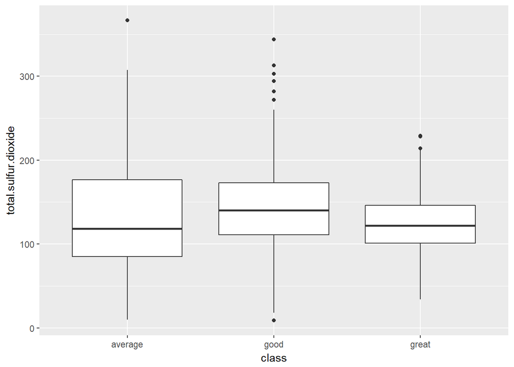

Our inference from this could be the fact that , There seems to be a a certain limit on the total sulpher dioxide which makes the wine a great wine. Though we can’t conclusively say it but can possible infer from the very graph above. The similar trend has been observed for average and good wines. We may need to check other parameters for a conclusion.

** Free Sulpher Dioxide **

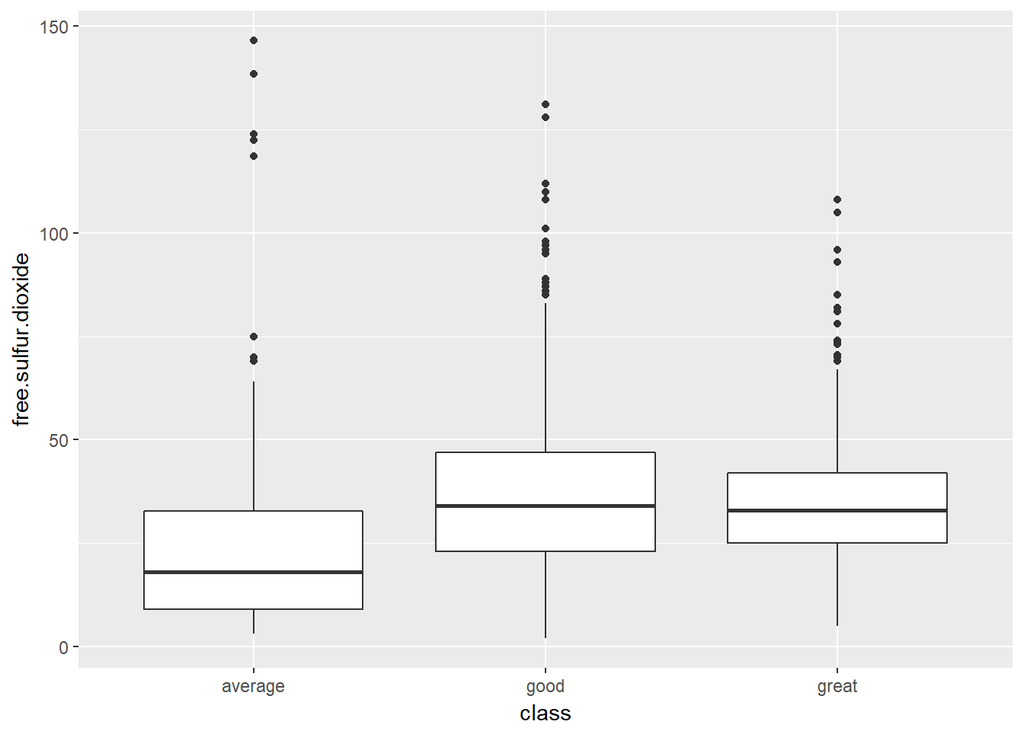